# HW4

Kwan Ho Lee

5/19/2021

## Problem 1

### 1a)

$$\int_0^1 x^2 dx$$

We use $f(x)=x^2$ and $p(x)=1$ uniform over the $[0,1]$ interval to approximate the integral using the formulation.

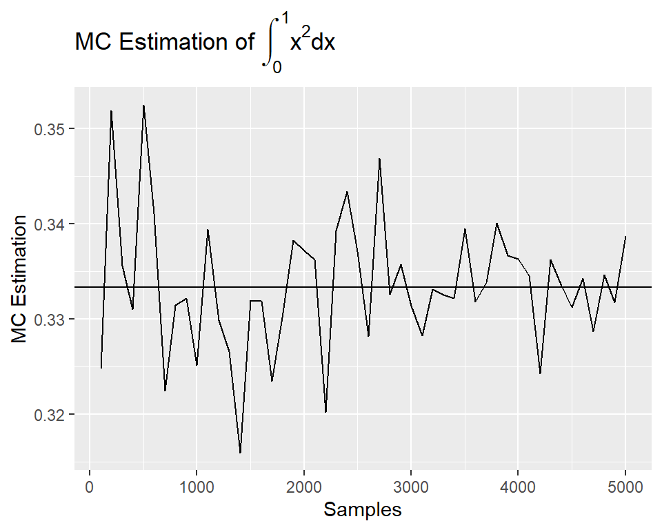

The Monte Carlo estimation of $\int_0^1 x^2 dx$ is $\hat{I}=0.3386958$. The exact evaluation is $I=\frac{x^3}{3}\bigg\rvert_0^1 = \frac{1}{3}$. Differnce is $\mid I-\hat{I}\mid=0.0053624$ which is only a factor of $\frac{\mid I-\hat{I}\mid}{1/3}=0.0160873$.

## 1c)

$$\int_{0}^{\infty} \frac{3}{4} x^4 e^{-x^3/4} dx$$
Notice that $\int_0^{\infty} e^{-x^3/4} dx = 2^{2/3}\Gamma(\frac{4}{3}) = k$ so we use
$$p(x) = \frac{1}{k}e^{-x^3/4}$$
and
$$f(x) = k\frac{3}{4}x^4$$
Then we substituted into the original integral, we see
$$\int_{0}^{\infty} \frac{3}{4} x^4 e^{-x^3/4} dx =
\int_{0}^{\infty} f(x) dp(x)$$

Hence, we sample from $p(x)$ using inverse CDF sampling and evaluate the samples at $f(x)$ for a large number of samples following the MC integration method. However, $P(x)=\int_0^{x}p(y)dy$ must first be calculated:
$$P(x) = \int_0^{x}p(y)dy =
\frac{1}{k}(k-\frac{x}{3}E_{2/3}(\frac{y^3}{4}))$$

where
$$E_n(x)=\int_1^{\infty} \frac{e^{-xt}}{t^n} dt =
x^{n-1}\Gamma(1-n,x)$$

and
$$\Gamma(a,x) = \int_x^\infty t^a e^{-t} dt$$

Finally, we calculate the inverse CDF and the CDF numerically.

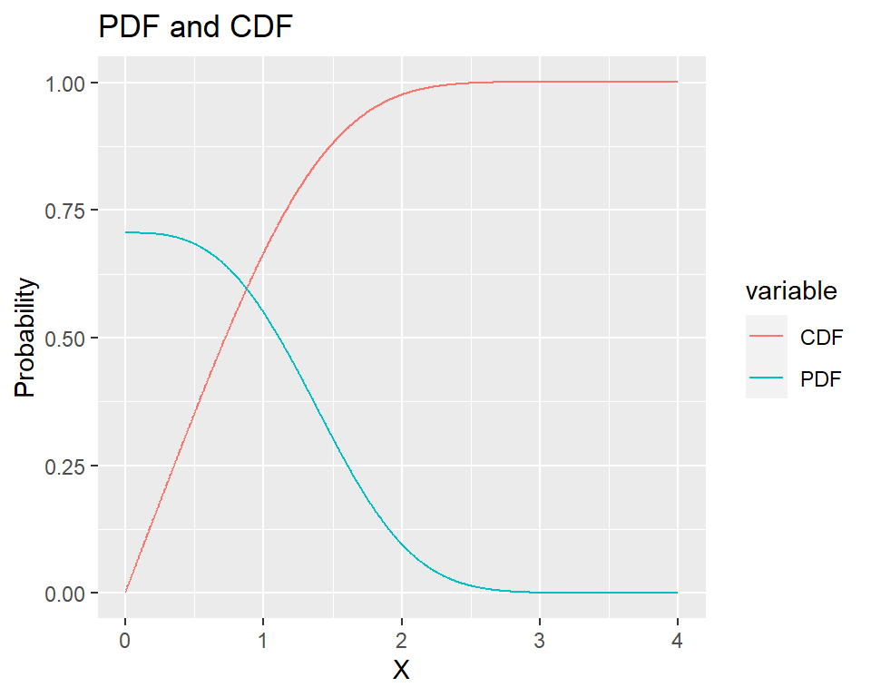

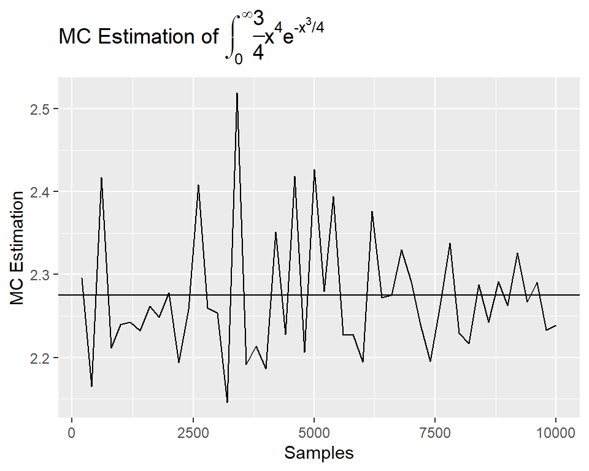

## Problem 2

Here we use importance sampling to approximate
$$I = \frac{1}{\sqrt{2\pi}} \int_{1}^{2} e^{-x^2/2} dx$$
using $f(x)=e^{-x^2/2}/\sqrt{2\pi}$ and $p(x)=\mathbf{1}_{x\in[1,2]}$. Importance sampling is the approximation of
$$\mu = E_p(f(x)) \approx \hat{\mu}_g =
\frac{1}{N}\sum_{i=1}^{N} \frac{f(x_i)p(x_i)}{g(x_i)}$$
where $X_i \sim g(X)$ iid. We rationalize this approximation using the law of large numbers and the fact that
$$\mu = E_p(f(x)) = \int_{D}f(x)dp(x) = \int_{D}\frac{f(x)g(x)}{g(x)}dp(x) =
\int_{D}\frac{f(x)p(x)}{g(x)}dg(x) = E_g(\frac{f(x)p(x)}{g(x)})$$
where $\frac{p(x)}{g(x)}$ is the *likelihood ratio*, $g(x)$ is the *importance distribution* given to be $g(x) = N(1.5,\nu)$ for $\nu\in\{0.1,1,10\}$, and $p(x)$ is the *nominal distribution*. In this problem, we use $p(x)\sim\mathbf{1}_{[1,2]}$ and $f(x)=e^{-x^2/2}/\sqrt{2\pi}$.

$$\hat{I}_{\nu=0.1}=0.0881578$$
$$\hat{I}_{\nu=1}=0.1346239$$
$$\hat{I}_{\nu=10}=0.1213762$$
The true value of the integral is
$$\int_1^2\frac{e^{-x^2/2}}{\sqrt{2\pi}}dx \approx 0.135905$$

Following we observe the histogram of the summands:

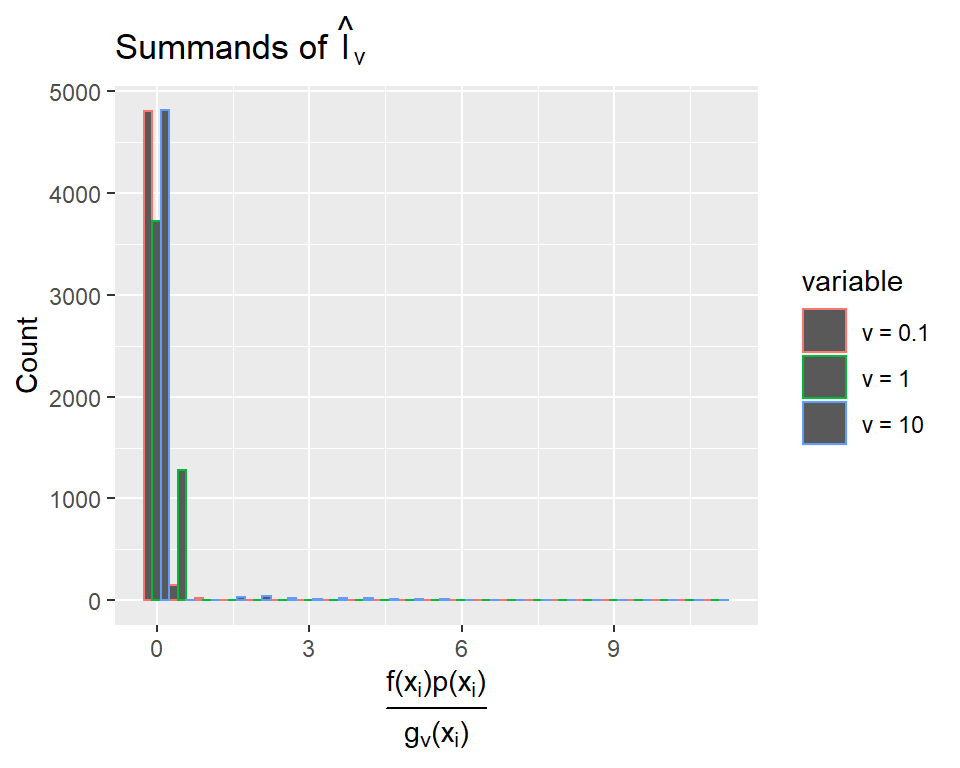

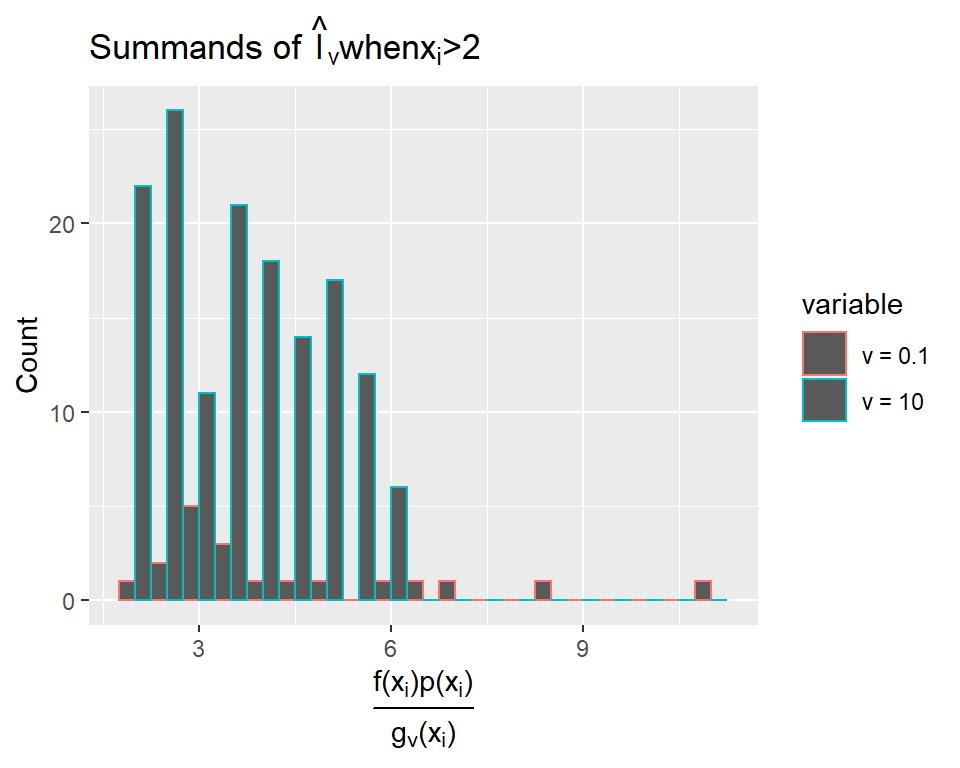

We observe that when the importance distribution is too wide or too narrow, there are many abberant values in the summand for the approximation $\hat{I} = \frac{1}{N}\sum_{i=1}^N \frac{f(x_i)p(x_i)}{g(x_i)}$.

## Problem 3

$$I=\int_0^1\frac{1}{1+x}dx$$

### 3a)

We simulate the integral using $h(x)=\frac{1}{1+x}$ and $U_i\sim U[0,1]$ for $i\in\{1,\dots,n\}$ in the model $I \approx \hat{I}_{MC} = \frac{1}{N} \sum_{i=1}^{N} h(u_i)$ where $u_i$ are the observations of the random variables $U_i$.

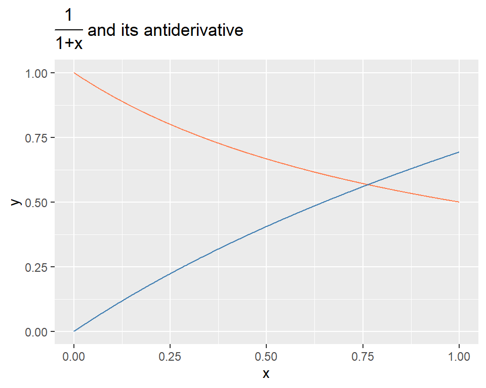

The pink line above is the function $h(x)=\frac{1}{1+x}$ and the blue line is $H(x)=\int_0^x h(t)dt$.

The MCMC estimate of the integral is $\hat{I}_{MC}=0.6885054$ compared with the true integral $I\approx 0.6931472$.

### 3b)

Using the control variate $c(x)=1+x$, we calculate $\hat{I}_{CV} = \frac{1}{N}\sum_{i=1}^N h(U_i) + b(\frac{1}{N}\sum_{i=1}^N c(U_i) - E(c(U)))$ where the variance of $\hat{I}_{CV}$ is minimized at $b=\frac{-cov(h(X), c(X))}{var(c(X))} \approx 0.476696$. Upon calculation, $\hat{I}_{CV}$ is realized as $0.6931881$.

### 3c)

The variance of $\hat{I}_{CV}$ is
$$Var(\hat{I}_{CV}) =
\frac{1}{N^2}Var(h(X)) - (\frac{b}{N})^2Var(c(X)) =
Var(\hat{I}_{MC}) - \frac{1}{N^2}\frac{Cov(h(X), c(X))^2}{Var(c(X))}$$

Running the MC and CV estimators $300$ times with $1500$ samples, $Var(\hat{I}_{MC}) \approx 1.3687825\times 10^{-5}$ and $Var(\hat{I}_{CV}) \approx 4.1128021\times 10^{-7}$. Notice that this is an improvement of $1.5221966$ orders of magnitude in the variance of the estimator.

### 3d)

A new estimator for $I$, $\hat{I}_{0}=\log 2$ has $0$ variance and $0$ bias. Alternatively, we could add another control variate ,for example $\hat{I}_{CV2} = \hat{I}_{CV} + b_2(\frac{1}{N}\sum_{i=1}^N c_2(U_i) - E(c_2(U)))$ where $c_2(x)=1-\frac{x}{2}$.

## Problem 4

### 4a)

Using the model $y_{ij}=\mu + \alpha_i + e_{ij}$ where $e_{ij}$ are sampled iid from a double exponential distribution, our null hypothesis $H_0$ is that $\alpha_i=0$ for all $i\in\{1,\dots,3\}$. The alternative hypothesis $H_A$ is that, for at least one $i^\star\in\{1,\dots,3\}$, $\alpha_{i^\star}\ne 0$.

To test the null hypothesis $H_0$ using Monte Carlo methods, we would execute the following algorithm:

```
Algorithm: Monte Carlo test
    input
        Y11...Y1N = Y.1,
        Y21...Y2N = Y.2,
        Y31...Y3N = Y.3,
            Observations for each of three treatments
        M,
            Number of samples for simulated emperical distribution
        K,
            Number of samples for each simulated statistic
        alpha
            Testing significance level
    output
        {0,1}
            0 if fail to reject H_0
            1 if reject H_0

m.hat = mean({Y1...YN})
b.hat = 1/2*sqrt(var(Y1...YN))
d.h0 = doubleExponential.pdf(mean=m.hat, sd=b.hat)

e.cdf = []
for i from 1 to M do:
    x.samp = sample(from=d.h0, n=K)
    x.stat = mean(x.samp)
    e.cdf.append(x.stat)

for i from 1 to 3 do:
    y.i.stat = mean(Y.i)
    if y.i.stat not in quantiles(e.cdf, alpha/2, 1-alpha/2) then:
        return 1
return 0
```

Hence, we generate a null empirical distribution using parameters estimated from the observed data and predicated on the $H_0$ model and reject the null hypothesis if any of the observed means for any of the treatments fall outside a reasonable simulated empirical quantile.

### 4b)

We could use Fisher’s 2-sample permutation method applied to each pair of treatments. Note that this scales poorly ($O(n!)$) with the number of treatments.

## Problem 5

### 5a)

We seek to sample $n=100$ times from $Poisson(\lambda r_i)$ with $r_i\sim Bernoulli(p)$ using $\lambda=2$ and $p=0.3$.

The sample generated using $p=0.3$ and $\lambda=2$ is below:

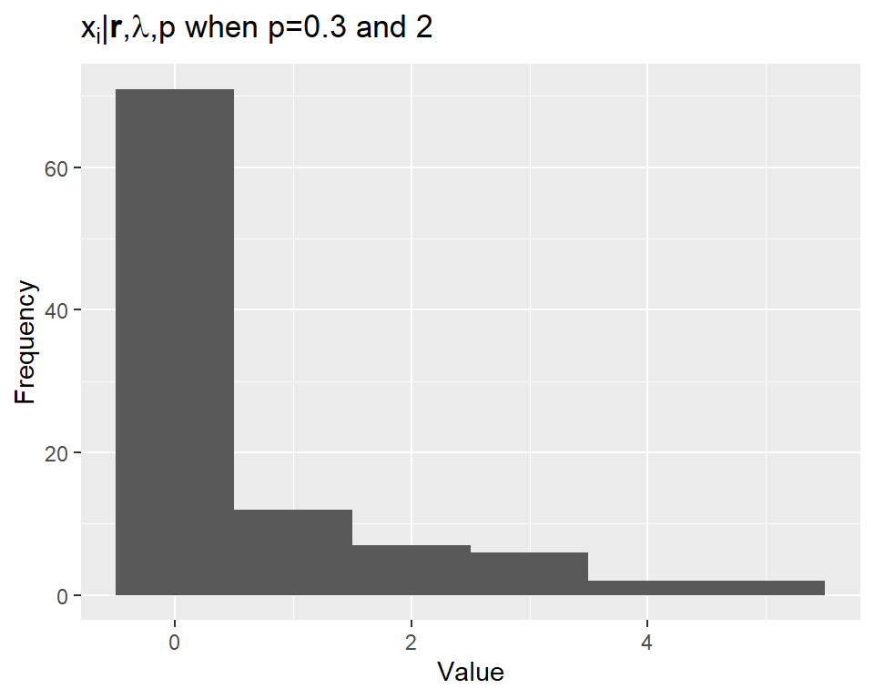

### 5b)

#### 5b).i

$$f(\lambda\mid p, r, x) =
\frac{b^a\lambda^{a-1}e^{-b\lambda}}{\Gamma(a)} p^{\sum(r_i)}
(1-p)^{n-\sum(r_i)} \prod\frac{r_i^{x_i}}{x_i!}
e^{-\lambda\sum r_i} \lambda^{\sum x_i} =$$
$$\lambda^{a+\sum x_i -1} e^{-(b+\sum r_i)\lambda} \frac{1}{N_{p,r,x}} =
\mathbf{\Gamma}_{a+\sum x_i, b+\sum r_i}(\lambda)$$

#### 5b).ii

$$f(\lambda\mid p, r, x) =
\frac{b^a\lambda^{a-1}e^{-b\lambda}}{\Gamma(a)} p^{\sum(r_i)}
(1-p)^{n-\sum(r_i)} \prod\frac{r_i^{x_i}}{x_i!}
e^{-\lambda\sum r_i} \lambda^{\sum x_i} =$$
$$p^{\sum r_i}(1-p)^{n-\sum r_i} \frac{1}{N_{\lambda, r, x}} =
\mathbf{\beta}_{\sum r_i, n-\sum r_i}(p)$$
where
$$\frac{1}{N_{\lambda, r, x}} =
\frac{b^a\lambda^{a-1}e^{-b\lambda}}{\Gamma(a)}
\prod\frac{r_i^{x_i}}{x_i!}
e^{-\lambda\sum r_i} \lambda^{\sum x_i}$$

#### 5b).iii

$$f(\lambda\mid p, r, x) =
\frac{b^a\lambda^{a-1}e^{-b\lambda}}{\Gamma(a)} p^{\sum(r_i)}
(1-p)^{n-\sum(r_i)} \prod\frac{r_i^{x_i}}{x_i!}
e^{-\lambda\sum r_i} \lambda^{\sum x_i} =$$
$$(\frac{b^a\lambda^{a-1}e^{-b\lambda}}{\Gamma(a)}) e^{-\lambda r_i}
(\lambda r_i)^{\sum x_i} (\prod\frac{1}{x_i!}) p^{r_i} (1-p)^{1-r_i} =
\frac{1}{N_{\lambda,x,p}} (e^{-\lambda}\frac{p}{1-p})^{r_i} r_i^{\sum x_i} =$$
$$Bernoulli(\frac{pe^{-\lambda}}{pe^{-\lambda} + (1-p)\mathbf{1}_{x_i=0}})$$

### 5c)

To sample from the posterior $f(\lambda, \mathbf{r}, p \mid \mathbf{x})$, we condition on the sample generated in part (5a). Then we expect to see high density around the values $p=0.3$ and $\lambda=2$ as were used to generate the sample.

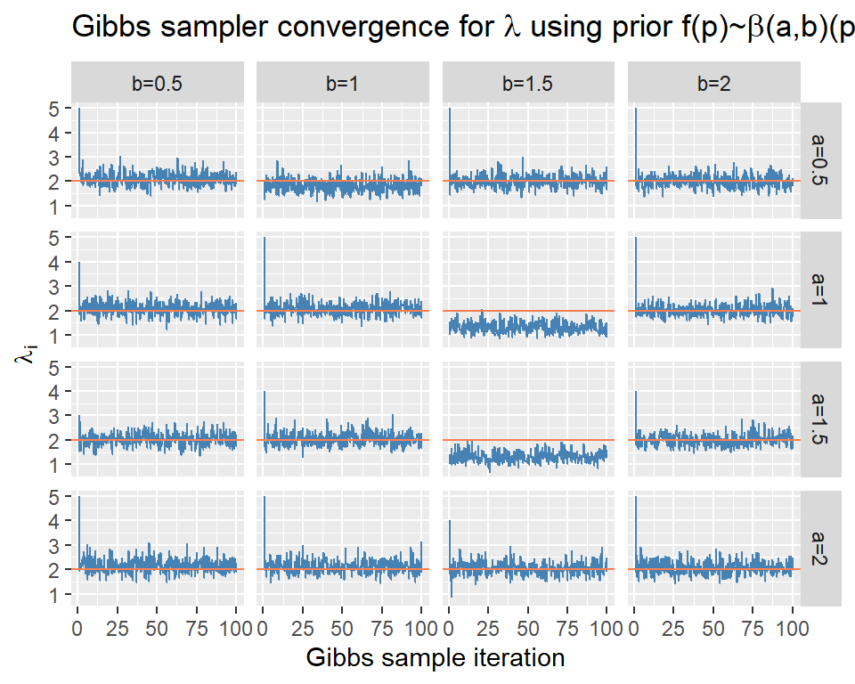

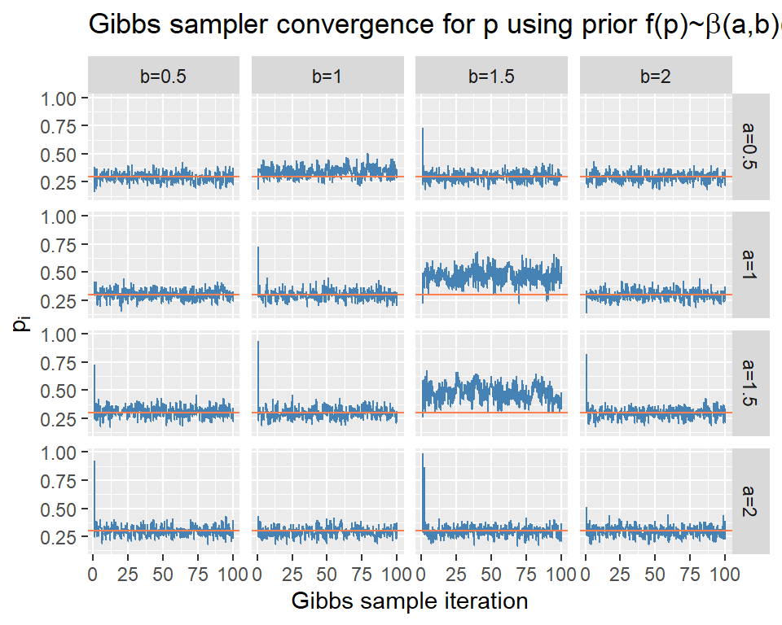

## Problem 6

$$f_{\theta_1,\theta_2}(z) \propto
z^{-3/2}e^{-\theta_1z-\frac{\theta_2}{z}+2\sqrt{\theta_1\theta_2}+
\log\sqrt{2\theta_2}}$$

We draw $1000$ samples by executing the following:

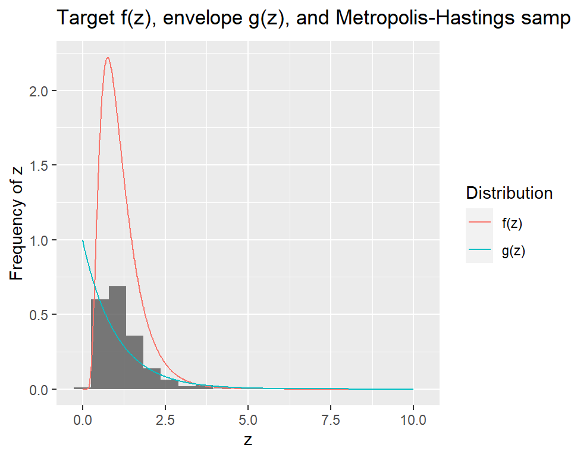

Notice that the sample in grey follows the target distribution in red rather than the sampling envelope in blue even though the target and envelope have a small inner product. Furthermore, we can test the accuracy of this simulation using the following the target distribution:

$$E_{f}(Z) = \sqrt{\frac{\theta_2}{\theta_1}} =
1.1547005
\quad \textrm{and} \quad
E_{f}(\frac{1}{Z}) = \sqrt{\frac{\theta_1}{\theta_2}} + \frac{1}{2\theta_2} =
1.1160254$$

In the sample produced by the M-H algorithm above:

$$\frac{1}{N}\sum_{i=1}^{N} z_i = 1.15011
\quad \textrm{and} \quad
\frac{1}{N}\sum_{i=1}^{N} \frac{1}{z_i} = 1.1424996$$

Notice that the test statistics and their true values are pretty close, indicating by another means that the sample is accurately drawn from $f(z)$

## Appendix

The following code is used in Question 1 part (a)

```r
library(ggplot2)
library(latex2exp)
set.seed(100)

# Define functions

f = function(x){
    return(x^2)
}
p = function(x){
    return(1)
}
f = Vectorize(f)
p = Vectorize(p)

## Parameterize

N = 5000
m = 50
K = 10000
v = 1

## Simulate

pxs = seq(0, 1, length.out=K)
i1s = rep(NA, m)
ns = (1:m)*N/m
for(i in 1:m){
    xs = sample(pxs, ns[i], prob=p(pxs), replace=T)
    i1 = v*mean(f(xs))
    i1s[i] = i1
}

## Plot

df_plt1 = data.frame(x = ns, y = i1s)
plt1 = ggplot(data=df_plt1, aes(x=x, y=y)) +
    geom_line() +
    geom_hline(yintercept = 1/3) +
    labs(
         x="Samples",
         y="MC Estimation",
         title=TeX("MC Estimation of $\\int_0^1 x^2 dx$")
         )
plt1
```

The following code is used in Question 1 part (c)

```r
library(reshape)

## Parameterize
N = 10000
m = 50
K = 1000
v = 1
mx = 4


## Define functions

k = 2^(2/3)*gamma(4/3)
f = function(x){
    return(k*3/4*x^4)
}
p = function(x){
    return(1/k*exp(-x^3/4))
}
f = Vectorize(f)
p = Vectorize(p)

## compute the CDF for inverse sampling

d = mx/K
pc_xs = seq(0, mx, by=d)
pdf = p(pc_xs)
cdf = cumsum(pdf)*d


# must calculate inverse cdf

us = seq(0, 1, length.out=K)
invcdf = rep(NA, K)
for(i in 1:length(us)){
    ix = sum(cdf<us[i]) + 1
    invcdf[i] = cdf[ix]
}

## Simulate
i3s = rep(NA, m)
ns = (1:m)*N/m

for(i in 1:m){
    xs = sample(pc_xs, ns[i], prob=pdf, replace=T)
    i3 = v*mean(f(xs))
    i3s[i] = i3
}

## Plot

pc_df = data.frame(x=pc_xs, CDF=cdf, PDF=pdf)
pc_df_m = melt(pc_df, id="x")
plt3 = ggplot(pc_df_m, aes(x=x, y=value, color=variable)) +
    geom_line() +
    labs(x="X", y="Probability", title="PDF and CDF")
plt3

# simulation results

tru = 2^(4/3)*gamma(5/3)
df_plt4 = data.frame(x = ns, y = i3s)
plt4 = ggplot(data=df_plt4, aes(x=x, y=y)) +
    geom_line() +
    geom_hline(yintercept = tru) +
    labs(
         x="Samples",
         y="MC Estimation",
         title=TeX(paste(
            "MC Estimation of",
            "$\\int_0^{\\infty} \\frac{3}{4} x^{4} e^{-x^3/4}$"
            ))
         )
plt4
```

The following code is used in Question 2

```r
## Define functions

g = function(n, u, sd){

    return(dnorm(n, mean=u, sd=sd))
}
p = function(x){

    if(x<1){return(0)}
    else if(x>2){return(0)}
    else{return(1)}
}
p = Vectorize(p)
f = function(x){

    r = exp(-x^2/2)/sqrt(2*pi)
    return(r)
}


## Parameterize

m = 5000
k = 10000
u = 1.5
vs = c(0.1, 1, 10) # standard deviations

## Simulate

samples = list()
summands = list()
i = 1
for(v in vs){
    d = c(-1, 1)*(4*v) + u
    domain = seq(d[1], d[2], length.out=k)
    ps = g(domain, u=u, sd=v)
    xs = sample(domain, m, prob=ps, replace=T)
    samples[[i]] = xs
    summands[[i]] = (f(xs)*p(xs))/(g(xs, u=u, sd=v))
    i = i + 1
}
```

```r
df_plt = data.frame(
                    sum1 = summands[[1]],
                    sum2 = summands[[2]],
                    sum3 = summands[[3]]
                )
names(df_plt) = c(
                  paste("v =", vs[1]),
                  paste("v =", vs[2]),
                  paste("v =", vs[3])
                )
df_plt_m = melt(df_plt) # format data


# plot data

plt1 = ggplot(
              data=df_plt_m,
              aes(x=value, color=variable)
            ) +
    geom_histogram(binwidth=0.5, position="dodge") +
    labs(
         x = TeX("$\\frac{f(x_i)p(x_i)}{g_v(x_i)}$"),
         y = "Count",
         title = TeX("Summands of $\\hat{I}_v$")
        )
plt1

# plot only observations larger than 2

plt2 = ggplot(
              data=df_plt_m[df_plt_m$value > 2,],
              aes(x=value, color=variable)
            ) +
    geom_histogram(binwidth=0.5, position="dodge") +
    labs(
         x = TeX("$\\frac{f(x_i)p(x_i)}{g_v(x_i)}$"),
         y = "Count",
         title = TeX("Summands of $\\hat{I}_v when x_i>2$")
        )
plt2
```

The following code is used in Question 3 part (a)

```r
## Parameterize
N = 1500
us = runif(N, 0, 1)
itru = log(2)
xs = seq(0,1,length.out=N)

## Define functions

h = function(x){
    if(x<0){return(0)}
    else if(x>1){return(0)}
    else{
        return(1/(1+x))
    }
}
h = Vectorize(h)

## Simulate

i1 = mean(h(us))

## Plot h and int(h)

df_3.a = data.frame(x=xs, y=h(xs))
df_3.a.2 = data.frame(x=xs, y=cumsum((1/N)*h(xs)))
plt_3.a = ggplot() +
    geom_line(data=df_3.a, aes(x=x, y=y), color="coral") +
    geom_line(data=df_3.a.2, aes(x=x, y=y), color="steelblue") +
    labs(title=TeX("$\\frac{1}{1+x}$ and its antiderivative"))

plt_3.a
```

The following code is used in Question 3 part (b)

```r
cc = function(x){
    if(x<0){return(0)}
    else if(x>1){return(0)}
    else{
        return(1+x)
    }
}
cc = Vectorize(cc)

b = -cov(h(xs), cc(xs)) / var(cc(xs))
i2 = mean(h(us)) + b*(mean(cc(us)) - 1.5)
```

The following code is used in Question 3 part (c)

```r
## Parameterize

M = 300

## Simulate

i1s = rep(NA, M)
i2s = rep(NA, M)

for(i in 1:M){
    us = runif(N)
    i1 = mean(h(us))
    i2 = mean(h(us)) + b*(mean(cc(us)) - 1.5)
    i1s[i] = i1
    i2s[i] = i2
}

v1 = var(i1s)
v2 = var(i2s)
```

The following code is used in Question 5 part (a)

```r
## Parameterize

n = 100
ltrue = 2
ptrue = 0.3

## Sample from prior

r = runif(n) < ptrue # r Bernoulli(p)

## Sample from posterior

xs = r * rpois(n, ltrue)

## Plot

df = data.frame(x=xs)
plt = ggplot(data=df, aes(x=x)) +
    geom_histogram(bins = max(xs)+1) +
    labs(
         x="Value",
         y="Frequency",
         title=TeX(
            "$x_i | \\textbf{r}, \\lambda, p$ when $p=0.3$ and $\\lambda=2$"
            )
        )
```

The following code is used in Question 5 part (c)

```r
## Parameterize

N = 400
A = seq(1/2, 2, by=1/2)
B = A



## Generate data frame

df.main = data.frame(matrix(NA,
                            length(A)*length(B)*N,
                            (5+n)
                        ))
names(df.main) = c("k", "p", "l", "a", "b", paste("r", 1:n, sep=""))

z = 0
for(a in A){for(b in B){

## Generate lambda, r, p randomly

r0 = runif(n) > rbeta(n, a, b)
l0 = ceiling(runif(1)*max(xs))
p0 = rbeta(1, a, b)
r1 = r0
l1 = l0
p1 = p0

Rs = matrix(NA, N, n)
ls = rep(NA, N)
ps = rep(NA, N)
Rs[1,] = r1
ls[1] = l1
ps[1] = p1

## Run the Gibbs sampler

for(i in 2:N){

    r1 = runif(n) < (p1*exp(-l0))/(p1*exp(-l0) + (1-p1)*(xs==0))
    l1 = rgamma(1, shape = a + sum(xs), rate = b + sum(r1))
    p1 = rbeta(1, 1 + sum(r1), n + 1 - sum(r1))


    Rs[i,] = r1
    ls[i] = l1
    ps[i] = p1
}

# Update the main dataframe (k, p, l, a, b, r1, ..., rn)

ixs = (1:N)+z*N
df.main[ixs,][1] = 1:n
df.main[ixs,][2] = ps   # estimate of p
df.main[ixs,][3] = ls   # estimate of lambda
df.main[ixs,][4] = a
df.main[ixs,][5] = b
df.main[ixs,][6:dim(df.main)[2]] = as.integer(Rs)
z = z + 1

}}

## Plot

plt_lambda = ggplot(data=df.main) +
    geom_line(aes(x=k, y=l), color="steelblue") +
    geom_hline(aes(yintercept=ltrue), color="coral") +
    facet_grid(a ~ b,
            labeller=labeller(
                a = (function (x) paste("a=", x, sep="")),
                b = (function (x) paste("b=", x, sep=""))
            )) +
    labs(x="Gibbs sample iteration",
         y=TeX("$\\lambda_i$"),
         title=TeX(paste(
            "Gibbs sampler convergence for $\\lambda$",
            "using prior $f(p)~\\beta(a,b)(p)$"
            ))
        )

plt_p = ggplot(data=df.main) +
    geom_line(aes(x=k, y=p), color="steelblue") +
    geom_hline(aes(yintercept=ptrue), color="coral") +
    facet_grid(a ~ b,
            labeller=labeller(
                a = (function (x) paste("a=", x, sep="")),
                b = (function (x) paste("b=", x, sep=""))
            )) +
    labs(x="Gibbs sample iteration",
         y=TeX("$p_i$"),
         title=TeX(paste(
            "Gibbs sampler convergence for $p$",
            "using prior $f(p)~\\beta(a,b)(p)$"
            ))
        )


plt_lambda
plt_p
```

The following code is used in Question 6

```r
## Parameterize

N = 1000
ran = seq(0, 10, by=0.01)
t1 = 1.5
t2 = 2

## Define functions

f = function(z){



    if(z<=0){return(0)}
    else if(t1<=0){return(0)}
    else if(t2<=0){return(0)}

    # Density
    r = z^(-3/2)*exp(-t1*z-t2/z+2*sqrt(t1*t2)+log(sqrt(2*t2)))
    return(r)
}
f = Vectorize(f)

g = function(z){
    # Envelope density g(z)

    return(dgamma(z, 1, 1))
}
g = Vectorize(g)

r = function(x,y){
    return(min(f(y)/f(x)*g(x)/g(y),1))
}

## Metropolis-Hastings algorithm

samp = rep(NA, N)
envelope = g(ran)
z0 = sample(size=1, x=ran, prob=envelope)
samp[1] = z0

for(i in 2:N){
    z1 = sample(size=1, x=ran, prob=envelope)
    a = r(z0,z1)
    if(a == 1){

        z0 = z1
    }else{

        if(a > runif(1)){

            z0 = z1
        }
    }
    samp[i] = z0
}

## Plot

dists_df = data.frame(x=ran, f=f(ran), g=g(ran))
plt_dists = ggplot(data=melt(dists_df, id="x")) +
    geom_line(aes(x=x, y=value, color=variable))

plt_methast = ggplot() +
    geom_histogram(
        data=melt(samp),
        aes(x=value, y=..density..),
        alpha=0.8, bins=N/50
    ) +
    geom_line(
        data=melt(dists_df, id="x"),
        aes(x=x, y=value, color=variable)
    ) +
    scale_colour_discrete(
        labels=c("f(z)", "g(z)"),
        name="Distribution"
    ) +
    labs(
        x="z", y="Frequency of z",
        title=TeX(paste(
            "Target $f(z)$,",
            "envelope $g(z)$,",
            "and Metropolis-Hastings sample",
            sep=" "
        ))
    )

plt_methast
```